# Rプログラミング入門 応用1：時系列の分解

Cho（ztempest0218@gmail.com）

Last Updated: 2026-06-22

**今回の内容**

- 古典的時系列分析：時系列の**分解**（トレンド・季節変動・不規則変動）
- 線形トレンドによる手動分解
- `stl()` による自動分解（局所回帰）
- 実戦：株価の移動平均線（5日・25日・50日、ゴールデンクロス、200日線）

**今回使用するデータ**

1. Yt.csv（練習用の四半期データ、6年分）
2. `nottem`、`AirPassengers`（Rに内蔵されている時系列データ）
3. 日経平均株価（`quantmod` でオンライン取得）

Yt.csv を[Rプログラミング入門授業用サイト](https://ztempest0218.github.io/R-Programming/)からダウンロードしてください。

まず、今回の分析で使うパッケージと、図の日本語フォント・テーマをまとめて読み込んでおく。

```r
library(tidyverse)
library(showtext)

# 日本語フォント
font_add_google("Noto Serif JP", "notojp")
showtext_auto()

# 図のテーマを統一（タイトルは中央寄せ）
theme_set(
  theme_minimal(base_family = "notojp") +
    theme(plot.title = element_text(hjust = 0.5))
)
```

# 1 古典的時系列分析：時系列の分解

第4回で学んだように、構造化データには大きく分けて、横断面データ、時系列データ、パネルデータの3種類がある。今回からは、その中でも**時系列データ**（time series data）に焦点を当てる。時系列データとは、特定の個体を複数時点にわたって継続的に観測したデータであり、GDP、株価、為替レート、CO₂濃度などが代表例である。

横断面データと違い、時系列データは観測値の「順序」に意味がある点が最大の特徴である。$y_1$ は第1期、$y_2$ は第2期…という並び順そのものが情報であり、勝手に入れ替えてはいけない。$t$ には、日次・月次・四半期・年次などの時間単位が対応する。

時系列分析の目標は、過去のショックの影響を測る **(1) 推定** と、将来の値を見通す **(2) 予測** に大別されるが、本格的な手法（ARIMA、状態空間モデル、VARなど）は専門科目で扱う。今回は、その入り口として、最も古典的で直感的な手法である**時系列の分解**を学ぶ。

古典的時系列分析の基本的な考え方は、時系列データをいくつかの成分に分解することである。これは、モデルのパラメータを推定する作業とは異なり、データそのものを構成要素に切り分ける**記述的**な作業である。

時系列データは、次の4つの成分に分解できると考える。

| 成分 | 記号 | 意味 |
| --- | --- | --- |
| トレンド（trend） | $T_t$ | 経済成長などの長期的な傾向 |
| サイクル（cycle） | $C_t$ | 景気循環などの周期的な変動 |
| 季節変動（seasonal） | $S_t$ | 季節・時期ごとに繰り返す変動 |
| 不規則変動（irregular） | $E_t$ | 予測できない不規則な変動（誤差） |

例えば、下図は実際の時系列データ（日経平均株価の日次終値）である。第4回で学んだ `quantmod` パッケージを使えば、株価データを簡単に取得できる。長期的に上昇する**トレンド**と、その周りで日々細かく上下する**不規則変動**が混在している様子が見て取れる（株価には、四半期データのような明確な季節変動はあまり見られない）。古典的時系列分析では、このような系列を上記の成分に切り分けていく。

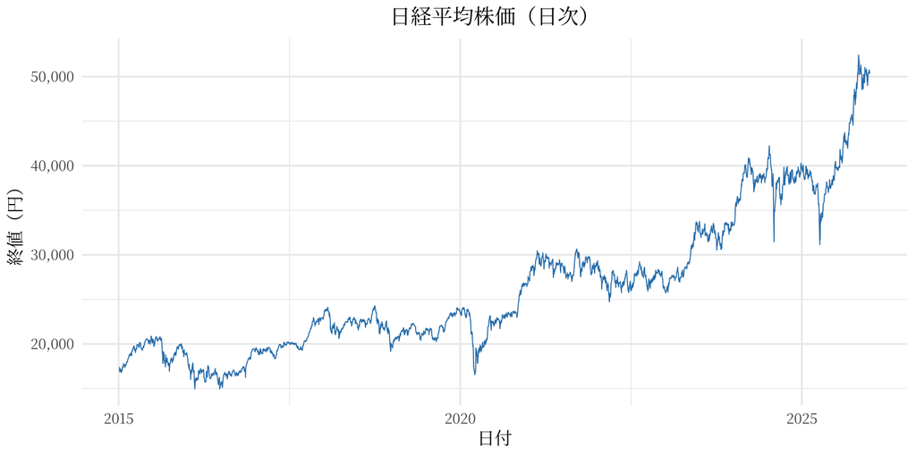

簡単化のため、本講義ではサイクル $C_t$ は存在しないものとする（循環を単独で取り出すには、HPフィルタなどマクロ経済学の知識が必要になるため、トレンドに含めて考える）。すると、時系列データ $y_t$ は次のように**加法的**に分解できると仮定する。

$$y_t = T_t + S_t + E_t$$

- $T_t$：トレンド成分（長期的な水準の動き）
- $S_t$：季節変動成分（毎年同じ時期に繰り返すパターン）
- $E_t$：不規則変動成分（残差）

分解の手順は、次の3ステップである。

1. **トレンドの抽出**：データ全体の長期的な動きを `lm()`（回帰）などで取り出す。
2. **季節変動の抽出**：トレンドを除いた残り（$y_t - T_t$）から、同じ季節どうしの平均をとる。
3. **不規則変動の抽出**：残った部分（$y_t - T_t - S_t$）をそのまま誤差とみなす。

# 2 線形トレンドによる手動分解

Rには季節・トレンド分解を一発で行う関数（後述の `stl()`）が用意されているが、**仕組みを理解するために、あえて自力で分解**してみる。これまで学んだ `lm()`、`predict()`、`dplyr` の `group_by()` だけで実装できる。

## 2.1 データの読み込みとプロット

`Yt.csv` は四半期ごとの架空データで、計24期（6年分）である。各年は春→夏→秋→冬の順に並んでいる。

```r
rm(list = ls())

# working directory は各自の環境に応じて設定すること
ts_data <- read.csv("./data/Yt.csv")

head(ts_data)
```

|  | t | Y |
| --- | --- | --- |
| 1 | 1 | 3.009648 |
| 2 | 2 | 2.521750 |
| 3 | 3 | 1.704029 |
| 4 | 4 | 3.727007 |
| 5 | 5 | 8.339746 |
| 6 | 6 | 6.983852 |

| 変数名 | 意味 |
| --- | --- |
| `t` | 期（1〜24）。`t = 1` が1年目の春、`t = 2` が夏… |
| `Y` | 観測値 |

まずは折れ線グラフでデータの形を確認する。時系列データは `geom_line()` で描くのが基本である。

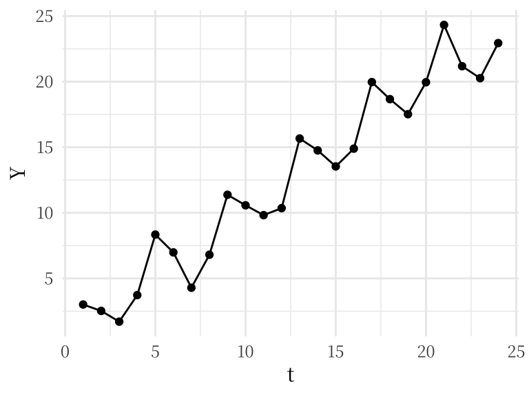

```r
ggplot(ts_data, aes(x = t, y = Y)) +
  geom_line() +
  geom_point() +
  labs(x = "t", y = "Y")
```

右上がりの長期的な傾向（トレンド）と、毎年繰り返す上下動（季節変動）が同時に存在していることが見て取れる。

## 2.2 ステップ1：トレンドの抽出

トレンドは、データ全体の長期的な動きである。ここでは最も単純な**線形（直線的）トレンド**を仮定する。すなわち、季節変動と不規則変動を誤差項とみなし、$y_t$ を時点 $t$ に回帰する。

$$y_t = \beta_0 + \beta_1 t + \varepsilon_t$$

これは第11回で学んだ単回帰そのものである。`lm()` で推定し、`predict()` で予測値を求めれば、それがトレンドの推定値 $\hat{T}_t$ になる。

```r
# 単回帰でトレンドを推定
reg <- lm(Y ~ t, data = ts_data)

# 予測値＝トレンド成分の推定値
ts_data <- ts_data %>%
  mutate(trend = predict(reg))

coef(reg)
```

```
## (Intercept)           t
##   0.6838729   0.9558684
```

```r
head(ts_data)
```

|  | t | Y | trend |
| --- | --- | --- | --- |
| 1 | 1 | 3.009648 | 1.639741 |
| 2 | 2 | 2.521750 | 2.595610 |
| 3 | 3 | 1.704029 | 3.551478 |
| 4 | 4 | 3.727007 | 4.507346 |
| 5 | 5 | 8.339746 | 5.463215 |
| 6 | 6 | 6.983852 | 6.419083 |

トレンドを元データに重ねて確認する。

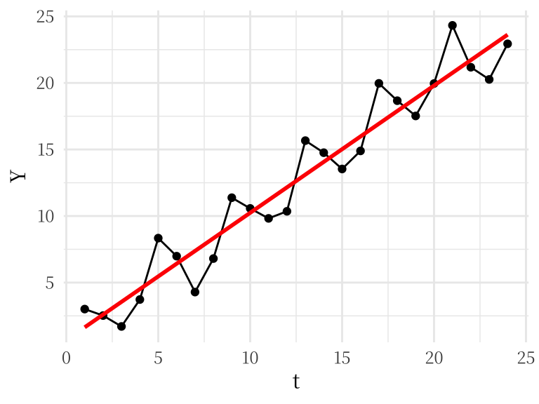

```r
ggplot(ts_data, aes(x = t, y = Y)) +
  geom_line() +
  geom_point() +
  geom_line(aes(y = trend), color = "red", linewidth = 1) +
  labs(x = "t", y = "Y")
```

赤い直線が線形トレンド $\hat{T}_t$ である。現実のデータでは直線とは限らないため、実際には多項式回帰や局所回帰（後述）も用いられる。

## 2.3 ステップ2：季節変動の抽出

次に、元データからトレンドを引いた残り（**トレンド除去後の系列**）を考える。

$$y_t - \hat{T}_t = S_t + E_t$$

この残りには、季節変動 $S_t$ と不規則変動 $E_t$ が含まれている。ここで、同じ季節どうしの平均をとれば、不規則変動が平均化されて消え、季節変動だけが残るという考え方を使う。

四半期データなので、季節は「春・夏・秋・冬」の4つである。`t = 1, 5, 9, 13, 17, 21` が春、`t = 2, 6, ...` が夏…と、4期ごとに同じ季節が繰り返す。各季節 $s \in \{\text{春},\text{夏},\text{秋},\text{冬}\}$ の季節効果 $\hat{S}_s$ は、その季節に該当する時点での「トレンド除去後の系列」の平均として求める。

$$\hat{S}_s
= \frac{1}{n_s}\sum_{t\,:\,\text{season}(t)=s}\bigl(y_t -
\hat{T}_t\bigr)$$

ここで $n_s$ はその季節の観測数（今回は各季節6年分で $n_s = 6$）である。例えば春の場合は、

$$\hat{S}_{\text{春}}
= \frac{1}{6}\sum_{t \in \{1,5,9,13,17,21\}}\bigl(y_t - \hat{T}_t\bigr)$$

となる。こうして得た季節効果を、各時点に $\hat{S}_t = \hat{S}_{\text{season}(t)}$ として割り当てる。実際の計算では、`rep()` で季節ラベルを作り、`dplyr` の `group_by()` で季節ごとの平均をとる。

```r
ts_data <- ts_data %>%
  mutate(
    # トレンド除去後の系列
    detrended = Y - trend,
    # 季節ラベル：春夏秋冬を6回繰り返す（6年分）
    season = rep(c("春", "夏", "秋", "冬"), times = 6),
    season = factor(season, levels = c("春", "夏", "秋", "冬"))
  )

# 季節ごとの平均＝季節効果
seasonal_effect <- ts_data %>%
  group_by(season) %>%
  summarise(seasonal = mean(detrended))

seasonal_effect
```

| season | seasonal |
| --- | --- |
| 春 | 2.5825459 |
| 夏 | 0.2923200 |
| 秋 | -1.9212687 |
| 冬 | -0.9535972 |

`rep(x, times = 6)` は「ベクトル `x` を6回繰り返す」コマンドである。第3回で学んだベクトル操作が、ここで役に立つ。

得られた季節効果（春・夏・秋・冬の4つの値）を、各期に割り当てる。`left_join()` を使えば、季節ラベルを key として季節効果を結合できる（第7回）。

```r
ts_data <- ts_data %>%
  left_join(seasonal_effect, by = "season")

head(ts_data, 8)
```

|  | t | Y | trend | detrended | season | seasonal |
| --- | --- | --- | --- | --- | --- | --- |
| 1 | 1 | 3.009648 | 1.639741 | 1.36990640 | 春 | 2.5825459 |
| 2 | 2 | 2.521750 | 2.595610 | -0.07385964 | 夏 | 0.2923200 |
| 3 | 3 | 1.704029 | 3.551478 | -1.84744937 | 秋 | -1.9212687 |
| 4 | 4 | 3.727007 | 4.507346 | -0.78033909 | 冬 | -0.9535972 |
| 5 | 5 | 8.339746 | 5.463215 | 2.87653087 | 春 | 2.5825459 |
| 6 | 6 | 6.983852 | 6.419083 | 0.56476866 | 夏 | 0.2923200 |
| 7 | 7 | 4.287566 | 7.374952 | -3.08738551 | 秋 | -1.9212687 |
| 8 | 8 | 6.805072 | 8.330820 | -1.52574838 | 冬 | -0.9535972 |

季節変動 $\hat{S}_t$ は、毎年まったく同じパターンが繰り返される。

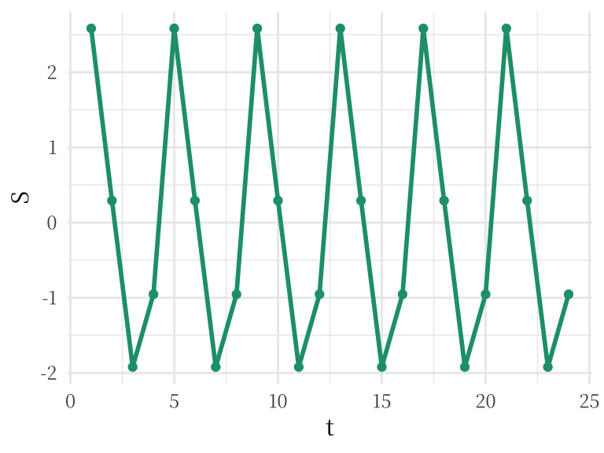

```r
ggplot(ts_data, aes(x = t, y = seasonal)) +
  geom_line(color = "#1B9E77", linewidth = 1) +
  geom_point(color = "#1B9E77") +
  labs(x = "t", y = "S")
```

## 2.4 ステップ3：不規則変動の抽出

最後に残るのが、不規則変動 $E_t$ である。これは、元データからトレンドと季節変動の両方を引いただけでよい。

$$\hat{E}_t = y_t - \hat{T}_t - \hat{S}_t$$

```r
ts_data <- ts_data %>%
  mutate(irregular = Y - trend - seasonal)

head(ts_data)
```

|  | t | Y | trend | detrended | season | seasonal | irregular |
| --- | --- | --- | --- | --- | --- | --- | --- |
| 1 | 1 | 3.009648 | 1.639741 | 1.36990640 | 春 | 2.5825459 | -1.21263951 |
| 2 | 2 | 2.521750 | 2.595610 | -0.07385964 | 夏 | 0.2923200 | -0.36617968 |
| 3 | 3 | 1.704029 | 3.551478 | -1.84744937 | 秋 | -1.9212687 | 0.07381934 |
| 4 | 4 | 3.727007 | 4.507346 | -0.78033909 | 冬 | -0.9535972 | 0.17325814 |
| 5 | 5 | 8.339746 | 5.463215 | 2.87653087 | 春 | 2.5825459 | 0.29398496 |
| 6 | 6 | 6.983852 | 6.419083 | 0.56476866 | 夏 | 0.2923200 | 0.27244863 |

不規則変動は、トレンドや季節では説明できなかった「ノイズ」であり、0の周りを不規則に動く。

## 2.5 結果をまとめてプロットする

4つの成分（元データ・トレンド・季節変動・不規則変動）を並べて確認する。ここでは、成分ごとに `ggplot` を1枚ずつ作り、`patchwork` パッケージで2×2に並べる。`patchwork` を読み込むと、`|`（横並び）と `/`（縦並び）だけで複数の図を自由にレイアウトできる。

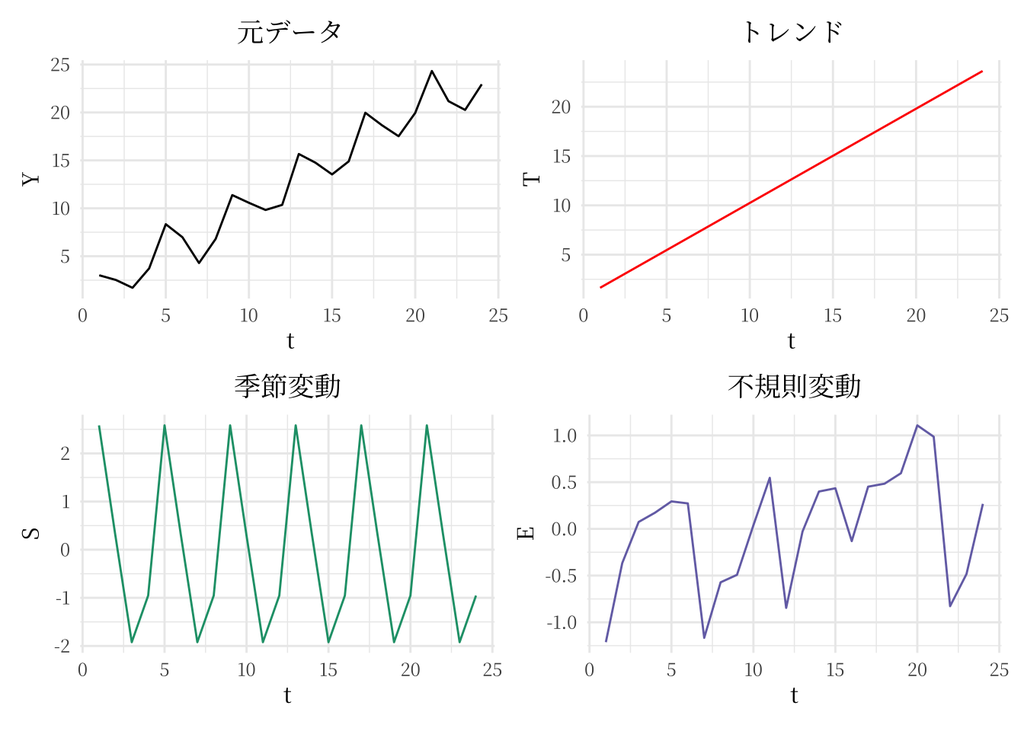

```r
# install.packages("patchwork")
library(patchwork)

p1 <- ggplot(ts_data, aes(t, Y)) +
  geom_line() +
  labs(title = "元データ", y = "Y")

p2 <- ggplot(ts_data, aes(t, trend)) +
  geom_line(color = "red") +
  labs(title = "トレンド", y = "T")

p3 <- ggplot(ts_data, aes(t, seasonal)) +
  geom_line(color = "#1B9E77") +
  labs(title = "季節変動", y = "S")

p4 <- ggplot(ts_data, aes(t, irregular)) +
  geom_line(color = "#7570B3") +
  labs(title = "不規則変動", y = "E")

(p1 | p2) / (p3 | p4)
```

このように、もとの時系列 $y_t$ が「長期トレンド」「毎年の季節パターン」「説明できないノイズ」の3成分に切り分けられた。3つを足し合わせれば、元データに戻る。

```r
# 検算：T + S + E がもとの Y に一致する
ts_data %>%
  mutate(reconstructed = trend + seasonal + irregular) %>%
  select(t, Y, reconstructed) %>%
  head()
```

|  | t | Y | reconstructed |
| --- | --- | --- | --- |
| 1 | 1 | 3.009648 | 3.009648 |
| 2 | 2 | 2.521750 | 2.521750 |
| 3 | 3 | 1.704029 | 1.704029 |
| 4 | 4 | 3.727007 | 3.727007 |
| 5 | 5 | 8.339746 | 8.339746 |
| 6 | 6 | 6.983852 | 6.983852 |

# 3 `stl()` による自動分解

先ほどの手動分解では線形トレンドを仮定したが、現実のトレンドは直線とは限らない。そこで、より柔軟な分解方法として、**局所回帰（local regression）** を用いた手法を紹介する。なお、ここで使う `stl()` は base R（`stats` パッケージ）に標準で備わっているため、`install.packages()` や `library()` は不要で、そのまま呼び出せる。`ts()` や内蔵データ（`nottem`、`AirPassengers`）も同様である。また、`stl()` は base R の機能であるため、結果の作図にも `ggplot2` ではなく base R の `plot()` を用いる（`plot(stl_オブジェクト)` で4成分がまとめて表示される）。

## 3.1 局所回帰（Loess）の考え方

非線形なトレンドであっても、**「局所的に見れば」直線で近似できる**。Cleveland et al. (1990) の **Loess**（locally estimated scatterplot smoothing）は局所回帰の一種であり、各時点の近傍だけを使って小さな直線をあてはめ、それらをつなぎ合わせることで、任意の滑らかな曲線（非線形トレンド）を推定する。

この発想は、**微分の考え方とよく似ている**。微分とは、ある1点で曲線を接線（1次関数）によって近似することであり、まさに「局所的な線形近似」である。Loess は、その局所線形近似を多数の点で行い、つなぎ合わせて曲線全体を捉えていると理解できる。

下図は、その直感を示したものである。滑らかな非線形トレンド（赤い曲線）の各点では、オレンジの短い直線（接線）で局所的に近似できる。これらの局所的な直線をつなぎ合わせたものが、曲線全体だと考えればよい。

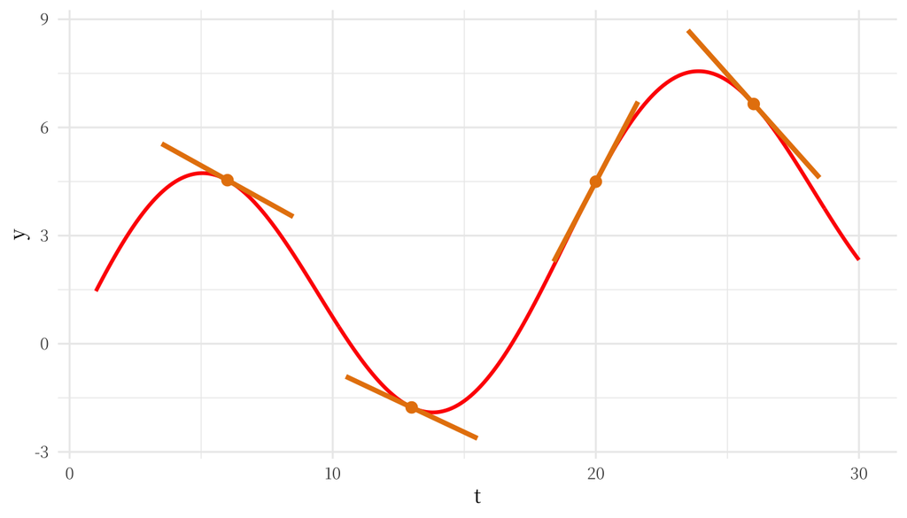

Rには、Loess を使った季節・トレンド分解を一発で実行する関数 **`stl()`**（Seasonal and Trend decomposition using Loess）が標準で実装されている。

## 3.2 `ts` 形式への変換

`stl()` を使うには、データを R の**時系列専用のデータ形式 `ts`**（time series）に変換する必要がある。`ts` 形式には、次のパラメータが含まれる。

| パラメータ | 意味 |
| --- | --- |
| `start` | データの最初の期 |
| `end` | データの最後の期 |
| `frequency` | データの周期 |

ここで、`ts` はこれまで使ってきた `data.frame` とは別物である点に注意してほしい。`data.frame` は日付を**1つの「列」として持つ**表形式であり、時間が不規則（飛び飛び）でもよい。一方、`ts` は数値ベクトルに `start`・`end`・`frequency` という**属性（メタ情報）を付けた**オブジェクトであり、日付専用の列を持たない。時刻は `start` と `frequency` から自動生成されるため、観測が**等間隔（規則的）であること**が前提になる。

|  | `data.frame` | `ts` |
| --- | --- | --- |
| 形 | 行 × 列の表 | 数値ベクトル＋属性 |
| 時間情報 | 日付「列」を持つ | `start`/`frequency` の属性として保持 |
| 時間間隔 | 不規則でも可 | 等間隔が前提 |
| 主な用途 | `dplyr`・`ggplot2` での前処理・可視化 | `stl()`・`decompose()`・`arima()` など古典的時系列関数 |

つまり、前処理や作図は `data.frame` で行い、`stl()` のような時系列専用の関数にかけるときだけ `ts` に変換する、という使い分けになる。

`frequency` は1年あたりの観測数を指定する。四半期データなら `4`、月次データなら `12` である。先ほど手動分解で用いた `Yt.csv` を `ts` 形式に変換してみよう。

```r
# 1年目の第1四半期から始まる、周期4（四半期）の時系列
Yt_ts <- ts(ts_data$Y, start = c(1, 1), frequency = 4)

Yt_ts
```

```
##        Qtr1      Qtr2      Qtr3      Qtr4
## 1  3.009648  2.521750  1.704029  3.727007
## 2  8.339746  6.983852  4.287566  6.805072
## 3 11.377289 10.572757  9.823208 10.355271
## 4 15.665451 14.758033 13.535009 14.893141
## 5 19.967830 18.665302 17.519548 19.955369
## 6 24.325863 21.177988 20.264000 22.938738
```

```r
# 時系列tsオブジェクトであることを確認
class(Yt_ts)
```

```
## [1] "ts"
```

```r
frequency(Yt_ts)
```

```
## [1] 4
```

### 3.2.1 どちらを使うべきか（歴史的な背景）

`ts` は R に古くからある時系列専用の形式で、`stl()` などの古い関数はこれを前提とする。一方、近年は `tidyverse` の普及で `data.frame` に統一するスタイルが主流である。**両者は互換性がない**ため、目的に応じて使い分ける。

- **データサイエンス全般**に興味がある人：基本は `data.frame`（`tibble`）。行×列で扱う考え方は Python の **pandas** とも共通する。
- **時系列を専門に**したい人：`ts` のほか `zoo`・`xts`（金融・不規則データ）、`tsibble`（tidyverse 流）など専用形式を検討するとよい。

## 3.3 内蔵データ `nottem` による分解

`nottem` は、1920年から1939年までのイギリス・ノッティンガムの**月平均気温**を記録した時系列データであり、Rに最初から組み込まれている。

```r
# すでに ts 形式
class(nottem)
```

```
## [1] "ts"
```

```r
frequency(nottem)   # 月次データなので 12
```

```
## [1] 12
```

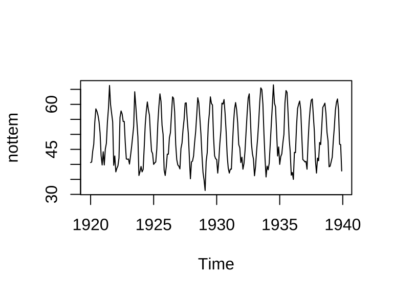

```r
plot(nottem)
```

夏に高く冬に低い、明らかな季節変動が存在する。

`stl()` で分解する。`s.window = "periodic"` は、季節変動を「毎年同じパターン（周期的）」として推定する指定である。

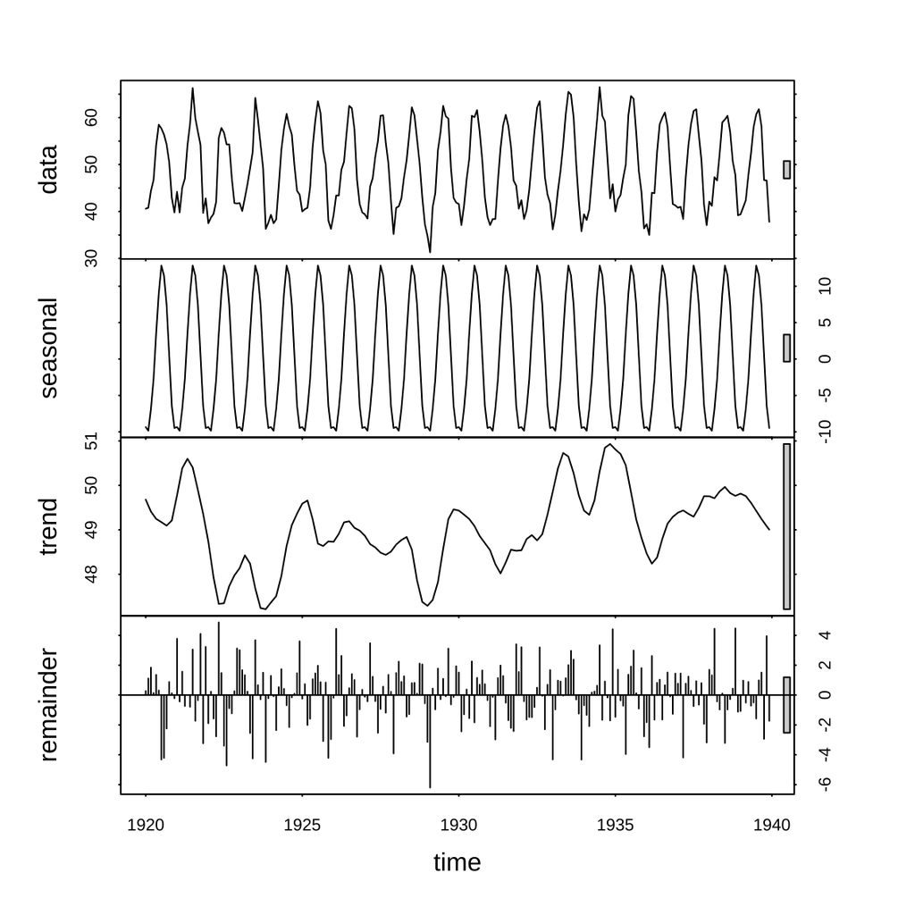

```r
stl_nottem <- stl(nottem, s.window = "periodic")

plot(stl_nottem)
```

出力は上から、`data`（元データ）、`seasonal`（季節変動）、`trend`（トレンド）、`remainder`（不規則変動）である。右側の縦棒（グレーのバー）は、各パネルの**スケールの目安**を表す。バーが短いパネルほど、元データに対する寄与が大きい。気温データでは季節変動の寄与が圧倒的に大きく、トレンドはほとんど見られない。

`stl()` の結果は、これまで学んだオブジェクトの考え方どおり、中に各成分が保存されている。

```r
# 分解結果（季節・トレンド・残差）の先頭を確認
head(stl_nottem$time.series)
```

```
##           seasonal    trend remainder
## Jan 1920 -9.347198 49.68067 0.2665254
## Feb 1920 -9.855250 49.54552 1.1097288
## Mar 1920 -6.853301 49.41037 1.8429318
## Apr 1920 -2.763471 49.32862 0.1348488
## May 1920  3.501357 49.24688 1.3517676
## Jun 1920  8.983303 49.21027 0.3064259
```

## 3.4 内蔵データ `AirPassengers` による分解

`AirPassengers` は、1949年から1960年までの国際線の月次航空旅客数を記録した、時系列分析で最も有名なデータの一つである。

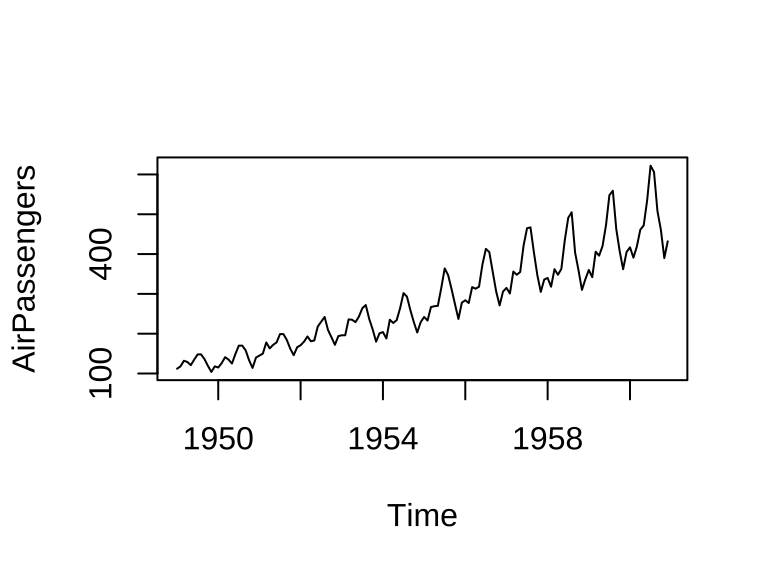

```r
plot(AirPassengers)
```

右上がりの明確なトレンド（航空需要の拡大）と、季節変動が同時に存在する。`stl()` を適用する。

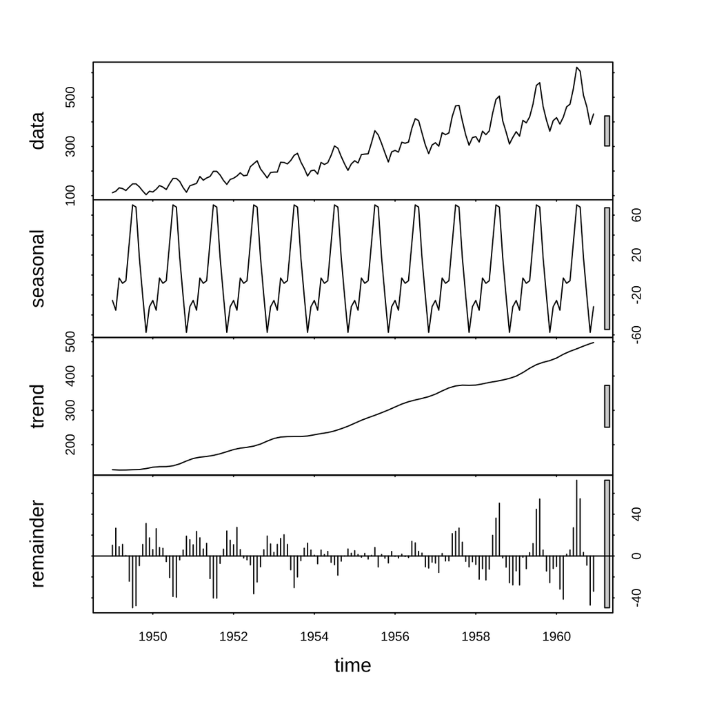

```r
stl_air <- stl(AirPassengers, s.window = "periodic")

plot(stl_air)
```

トレンドは一貫して上昇している。季節成分を確認すると、夏休みシーズンの **7〜8月に旅客数が多く**なる周期パターンが読み取れる。

```r
# 季節成分だけを取り出して1年分を確認
stl_air$time.series[1:12, "seasonal"]
```

```
##  [1] -25.497718 -35.220935  -3.027478  -8.299054  -5.737289  32.336634
##  [7]  70.243882  68.049433  17.438326 -21.063432 -57.481851 -31.740516
```

このように、`stl()` を使えば、線形トレンドを仮定しなくても、データに合わせた柔軟な分解が自動的に得られる。仕組みを理解した上で、実務では `stl()` のような既存関数を活用するのが効率的である。

# 4 実戦：株価の移動平均線

ここまで、トレンドの抽出には回帰（線形トレンド）と Loess（局所回帰）を用いた。実務、とくに金融の世界で最もよく使われるトレンド抽出法が、**移動平均**（moving average, MA）である。株価チャートに表示される「5日線」「25日線」「50日線」は、すべて移動平均によってトレンドを平滑化したものである。

**なお、本節はあくまで R の操作例であり、投資アドバイスではない。記載内容に基づくいかなる損失についても一切責任を負わない。**

## 4.1 移動平均とは

移動平均とは、**「直近 $k$ 期分のデータの平均」を1期ずつずらしながら計算した系列**である。$k$ 日移動平均（$k$日線）は次のように定義される。

$$\text{MA}_t(k) = \frac{1}{k}\sum_{i=0}^{k-1} y_{t-i}
= \frac{y_t + y_{t-1} + \cdots + y_{t-k+1}}{k}$$

これは、最も単純な**トレンドの平滑化**である。短期的なノイズ（不規則変動）を平均によってならし、長期的な動き（トレンド）だけを浮かび上がらせる。期間 $k$ を大きくするほど、線は滑らかになり、反応は鈍くなる。

| 平均の取り方 | 定義 | 主な用途 |
| --- | --- | --- |
| 後方移動平均（trailing） | 直近 $k$ 期の平均 | 株価チャート（過去だけで計算） |
| 中心化移動平均（centered） | 前後対称の $k$ 期の平均 | 古典的な季節・トレンド分解 |

多くの分析では、データが揃っているため前後対称の**中心化移動平均**を使う。一方、株価のように未来の情報を持てない場合は、**過去の情報だけ**を使って計算する後方移動平均を用いる。

## 4.2 株価データの取得

第4回で学んだ `quantmod` パッケージを使い、日経平均株価（^N225）を取得する。

```r
# install.packages("quantmod")
library(quantmod)

# 日経平均を取得
n225 <- getSymbols(
  "^N225",
  src = "yahoo",
  from = "2024-01-01",
  to = "2025-12-31",
  auto.assign = FALSE
)

head(n225)
```

```
##            N225.Open N225.High N225.Low N225.Close N225.Volume N225.Adjusted
## 2024-01-04  33193.05  33299.39 32693.18   33288.29   117300000      33288.29
## 2024-01-05  33397.52  33568.04 33257.43   33377.42   115300000      33377.42
## 2024-01-09  33704.83  33990.28 33600.32   33763.18   112100000      33763.18
## 2024-01-10  33896.33  34539.02 33885.74   34441.72   106000000      34441.72
## 2024-01-11  34871.33  35157.56 34849.57   35049.86   130100000      35049.86
## 2024-01-12  35601.65  35839.65 35362.24   35577.11   129200000      35577.11
```

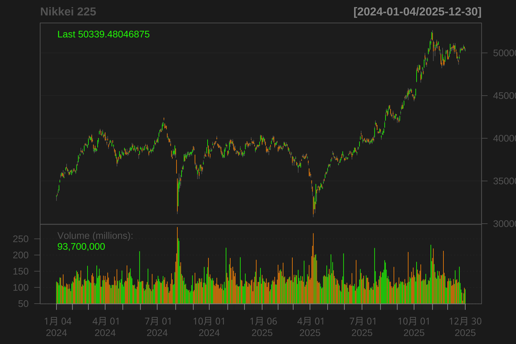

```r
# quantmod の chartSeries で時系列を描く
chartSeries(n225, name = "Nikkei 225")
```

`getSymbols()` が返すのは `xts` という時系列専用オブジェクトである。`xts` は時刻を「索引」として持つ行列（matrix）であり、`dplyr` や `ggplot2` をそのまま適用できない。そこで、日付と終値（Close）だけを取り出して `data.frame` に変換する。日付を1つの列にすれば、これまで通り `dplyr`・`ggplot2` で扱える。`Cl()` は終値の列を取り出す `quantmod` の関数である。

```r
stock <- data.frame(
  date  = index(n225),
  close = as.numeric(Cl(n225))
) %>%
  # 休場日などで生じる欠損を除く
  filter(!is.na(close))

head(stock)
```

|  | date | close |
| --- | --- | --- |
| 1 | 2024-01-04 | 33288.29 |
| 2 | 2024-01-05 | 33377.42 |
| 3 | 2024-01-09 | 33763.18 |
| 4 | 2024-01-10 | 34441.72 |
| 5 | 2024-01-11 | 35049.86 |
| 6 | 2024-01-12 | 35577.11 |

## 4.3 5日・25日・50日移動平均を計算する

移動平均は、`zoo` パッケージの `rollmeanr()`（right-aligned = 後方移動平均）で計算できる。`fill = NA` は、計算に必要な期間がそろわない最初の数日を `NA` で埋める指定である。例えば5日線は、最初の4日分は計算できない。

```r
library(zoo)

stock <- stock %>%
  mutate(
    ma5  = rollmeanr(close, k = 5,  fill = NA),
    ma25 = rollmeanr(close, k = 25, fill = NA),
    ma50 = rollmeanr(close, k = 50, fill = NA)
  )

# 最初の数日は ma が NA になっている
head(stock, 6)
```

|  | date | close | ma5 | ma25 | ma50 |
| --- | --- | --- | --- | --- | --- |
| 1 | 2024-01-04 | 33288.29 | NA | NA | NA |
| 2 | 2024-01-05 | 33377.42 | NA | NA | NA |
| 3 | 2024-01-09 | 33763.18 | NA | NA | NA |
| 4 | 2024-01-10 | 34441.72 | NA | NA | NA |
| 5 | 2024-01-11 | 35049.86 | 33984.09 | NA | NA |
| 6 | 2024-01-12 | 35577.11 | 34441.86 | NA | NA |

```r
# 直近の値を確認
tail(stock)
```

|  | date | close | ma5 | ma25 | ma50 |
| --- | --- | --- | --- | --- | --- |
| 483 | 2025-12-23 | 50412.87 | 49767.25 | 49821.39 | 49864.00 |
| 484 | 2025-12-24 | 50344.10 | 49933.61 | 49887.03 | 49909.10 |
| 485 | 2025-12-25 | 50407.79 | 50214.87 | 49961.84 | 49980.31 |
| 486 | 2025-12-26 | 50750.39 | 50463.51 | 49998.89 | 50041.87 |
| 487 | 2025-12-29 | 50526.92 | 50488.41 | 50074.93 | 50086.85 |
| 488 | 2025-12-30 | 50339.48 | 50473.74 | 50142.13 | 50142.00 |

補足：`quantmod` には `SMA()`（Simple Moving Average）という関数もあり、`SMA(Cl(n225), n = 5)` のように直接 `xts` から計算することもできる。ここでは `data.frame` 上で `dplyr` と組み合わせて扱うため `rollmeanr()` を用いた。

## 4.4 移動平均線を可視化する

終値（細い灰色）に、3本の移動平均線を重ねて描く。期間が長い線ほど滑らかで、株価の動きに遅れて反応することが確認できる。

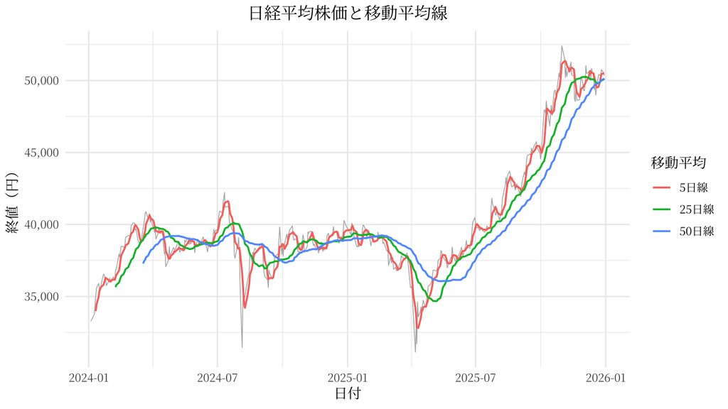

```r
ggplot(stock, aes(x = date)) +
  geom_line(aes(y = close), color = "gray70", linewidth = 0.3) +
  geom_line(aes(y = ma5,  color = "5日線"),  linewidth = 0.7) +
  geom_line(aes(y = ma25, color = "25日線"), linewidth = 0.7) +
  geom_line(aes(y = ma50, color = "50日線"), linewidth = 0.7) +
  labs(
    title = "日経平均株価と移動平均線",
    color = "移動平均",
    x = "日付", y = "終値（円）"
  ) +
  scale_color_discrete(limits = c("5日線", "25日線", "50日線")) +
  scale_y_continuous(labels = scales::comma)
```

短期線（5日線）は株価にほぼ張り付くように細かく動き、長期線（50日線）は大きな流れだけを表す。これは、移動平均がトレンドの平滑化、すなわち**ローパスフィルタ（高周波のノイズを除去する仕組み）**として働いているためである。

補足：日本株では `5日 / 25日 / 75日` がよく使われ（おおむね1週・1か月・3か月の営業日に対応）、米国株では `50日 / 200日` が代表的である。本演習では授業の指定どおり 5・25・50 を用いたが、何日線を見るかは分析の時間軸によって選ぶ。

## 4.5 ゴールデンクロスとデッドクロス

テクニカル分析では、**短期線が長期線を下から上に抜ける**ことを **ゴールデンクロス**（上昇トレンドへの転換シグナルとされる）、**短期線が長期線を上から下に抜ける**ことを **デッドクロス**（下降トレンドへの転換シグナルとされる）と呼ぶ。

ここで重要なのは、ゴールデンクロス・デッドクロスは「**短期線と長期線**」の組み合わせ全般を指す一般的な概念であり、特定の日数に限定されるものではないという点である。どの2本を使うかは慣習や分析の時間軸によって異なり、米国株では `50日線 × 200日線`、日本株では `5日線 × 25日線` や `25日線 × 75日線` などがよく使われる。ここでは一例として、25日線（短期）と50日線（長期）の位置関係から、クロスが発生した日を機械的に検出してみる。`lag()` は1期前の値を取り出す `dplyr` の関数である。

```r
crosses <- stock %>%
  mutate(
    diff = ma25 - ma50,                       # 短期線 − 長期線
    signal = case_when(
      lag(diff) < 0 & diff >= 0 ~ "ゴールデンクロス",
      lag(diff) > 0 & diff <= 0 ~ "デッドクロス"
    )
  ) %>%
  filter(!is.na(signal)) %>%
  select(date, ma25, ma50, signal)

crosses
```

| date | ma25 | ma50 | signal |
| --- | --- | --- | --- |
| 2024-04-26 | 39098.70 | 39198.57 | デッドクロス |
| 2024-06-13 | 38700.14 | 38661.66 | ゴールデンクロス |
| 2024-08-08 | 38882.75 | 38921.49 | デッドクロス |
| 2024-09-27 | 37571.12 | 37530.61 | ゴールデンクロス |
| 2024-12-04 | 38732.38 | 38740.00 | デッドクロス |
| 2024-12-10 | 38817.48 | 38788.98 | ゴールデンクロス |
| 2024-12-11 | 38813.15 | 38818.03 | デッドクロス |
| 2024-12-23 | 38892.66 | 38884.49 | ゴールデンクロス |
| 2025-02-12 | 39164.91 | 39167.17 | デッドクロス |
| 2025-05-21 | 36142.57 | 36069.69 | ゴールデンクロス |

[output cut: 2 more lines]

検出したクロスを、先ほどの図に印として重ねる。

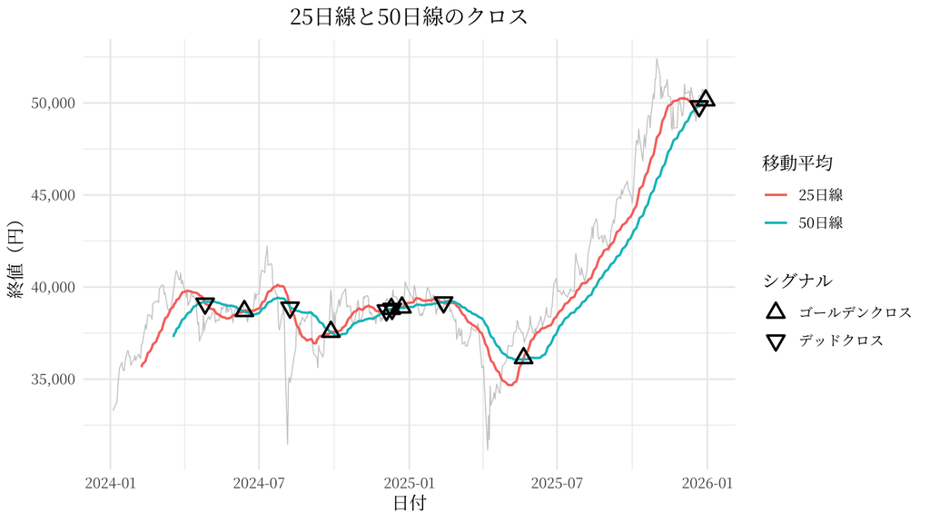

```r
ggplot(stock, aes(x = date)) +
  geom_line(aes(y = close), color = "gray80", linewidth = 0.3) +
  geom_line(aes(y = ma25, color = "25日線"), linewidth = 0.7) +
  geom_line(aes(y = ma50, color = "50日線"), linewidth = 0.7) +
  geom_point(data = crosses, aes(y = ma25, shape = signal), size = 3, stroke = 1.1) +
  scale_shape_manual(
    name = "シグナル",
    values = c("ゴールデンクロス" = 2, "デッドクロス" = 6)
  ) +
  labs(
    title = "25日線と50日線のクロス",
    color = "移動平均",
    x = "日付", y = "終値（円）"
  ) +
  scale_y_continuous(labels = scales::comma)
```

## 4.6 200日移動平均とトレンドフィルター

実務、とくに機関投資家（バイサイド）の世界では、**200日移動平均線**（200日線）が長期トレンドの基準として重視される。多くの投資会社には、**「株価が200日線を上回るまで買い増しを認めない」** といったリスク管理ルールがあり、200日線を**順張りのトレンドフィルター**として使う。

- 株価が200日線より**上** → 上昇トレンドとみなし、買い増しを許容する。
- 株価が200日線より**下** → 下降トレンドとみなし、買い増しを制限する。

実際に、株価が200日線の上にあった日の割合を計算してみよう。

```r
stock <- stock %>%
  mutate(
    ma200  = rollmeanr(close, k = 200, fill = NA),
    regime = if_else(close >= ma200, "200日線より上", "200日線より下")
  )

# 200日線が計算できる期間だけで集計
stock %>%
  filter(!is.na(ma200)) %>%
  count(regime) %>%
  mutate(share = round(n / sum(n) * 100, 1))
```

| regime | n | share |
| --- | --- | --- |
| 200日線より上 | 205 | 70.9 |
| 200日線より下 | 84 | 29.1 |

次に、終値と200日線を描き、200日線を下回っていた局面（＝買い増しが制限される期間）を背景の赤い帯で示す。トレンドフィルターが「いつ買い増しを止めるか」を視覚的に確認できる。

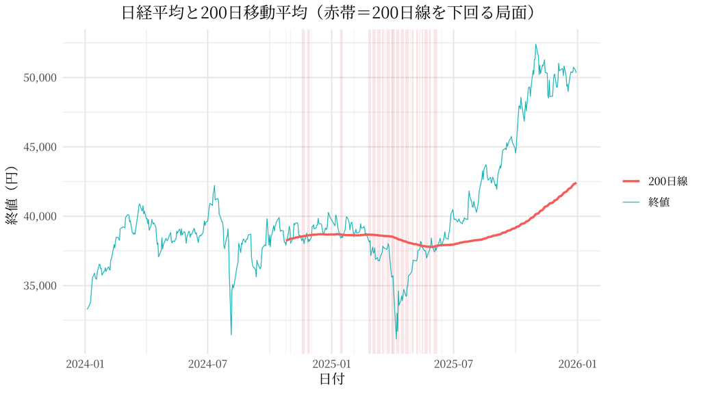

```r
# 200日線より下の日だけを抽出（背景の帯に使う）
below_200 <- stock %>%
  filter(!is.na(ma200), regime == "200日線より下")

ggplot(stock, aes(x = date)) +
  geom_rect(
    data = below_200,
    aes(xmin = date - 0.5, xmax = date + 0.5, ymin = -Inf, ymax = Inf),
    fill = "#D7191C", alpha = 0.10, inherit.aes = FALSE
  ) +
  geom_line(aes(y = close, color = "終値"), linewidth = 0.3) +
  geom_line(aes(y = ma200, color = "200日線"), linewidth = 0.9) +
  labs(
    title = "日経平均と200日移動平均（赤帯＝200日線を下回る局面）",
    color = NULL, x = "日付", y = "終値（円）"
  ) +
  scale_y_continuous(labels = scales::comma)
```

赤い帯の期間は、ルール上「買い増し禁止」とされる局面である。移動平均は、感情に流されず決めた基準で判断するための「物差し」である。ただし万能ではない。本質的に**遅行指標**（lagging indicator）であり、レンジ相場では「ダマシ」も多い。第11回と同じく、**クロスは過去を平滑化した結果にすぎず、将来を保証しない**。実務では、ファンダメンタルズと併せて総合的に判断する。

重要なのは、移動平均も「トレンドの平滑化」であり、本講義の分解と同じ枠組みにある点である。回帰・Loess・移動平均は、いずれも $y_t$ からトレンド $T_t$ を取り出す手段である。

# 5 課題

HW5の〆切は2026年7月8日16:30までです。下記リンクで受領してください。

HW5 https://classroom.github.com/a/tUvsH3mx

# 6 参考資料

- Cleveland, R. B., Cleveland, W. S., McRae, J. E., and Terpenning, I. (1990). “STL: A Seasonal-Trend Decomposition Procedure Based on Loess.” *Journal of Official Statistics*, 6(1), 3-73.
- 沖本竜義 (2010). 『経済・ファイナンスデータの計量時系列分析』朝倉書店.